# **Child Stunting : Story of an hidden crisis**

*Sources : UN, WHO, UNICEF*

Author

Marie BELLAN

Published

April 25, 2025

# **What is child stunting?**

Today, **one in five children** under the age of five falls short of WHO growth standards—a condition known as stunting.  
While **malnutrition** is often considered as the main cause of stunting, in most cases we observe a more complex narrative. Indeed, **repeated infections, contaminated water sources, entrenched poverty, and limited maternal education** play as big a role as acute malnutrition.

**This challenge is multidimensional**, affecting the physical but also the cognitive development of **more than 149 millions of children in 2022** (WHO, 2024) and putting them in danger.

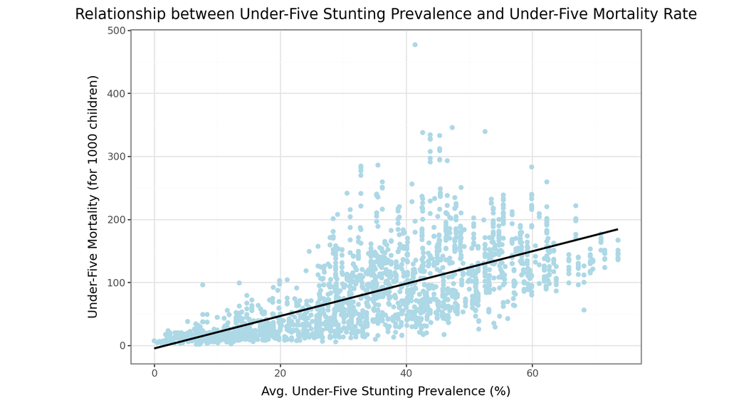

```python
import pandas as pd
import plotnine
from plotnine import (
    ggplot,
    aes,
    geom_point,
    geom_smooth,
    labs,
    theme_bw
)
df_stunting = pd.read_excel("unicef_indicator_2_quarto_vo.xlsx")
df_u5mr = pd.read_excel("U5MR_corrected.xlsx")
df_stunting_total = df_stunting[df_stunting['sex'] == 'Total'].copy()
df_stunting_total.rename(columns={'time_period': 'year', 'stunting_prevalence_pourcentage': 'stunting_prevalence'}, inplace=True)
df_stunting_total = df_stunting_total[['country', 'year', 'stunting_prevalence']]
df_u5mr.rename(columns={'year': 'year', 'U5MR_estimate': 'u5mr'}, inplace=True)
df_u5mr = df_u5mr[['country', 'year', 'u5mr']]
df_merged = pd.merge(df_stunting_total, df_u5mr, on=['country', 'year'], how='inner')
(ggplot(df_merged, aes(x='stunting_prevalence', y='u5mr'))
    + geom_point(color='#ADD8E6')
    + geom_smooth(method='lm', se=False, color='black')
    + labs(
        title='Relationship between Under-Five Stunting Prevalence and Under-Five Mortality Rate',
        x='Avg. Under-Five Stunting Prevalence (%)',
        y='Under-Five Mortality (for 1000 children)'
    )
    + theme_bw()
    + coord_fixed(ratio=0.1)
    + theme_bw()
    + theme(figure_size=(9,5)))
```

The most alarming consequence of stunting is the **significantly increased risk of mortality**. Stunted children have a **weaker immune system**, which makes them **more susceptible to infectious diseases** and other aggravating environmental factors.

# **Who is affected?**

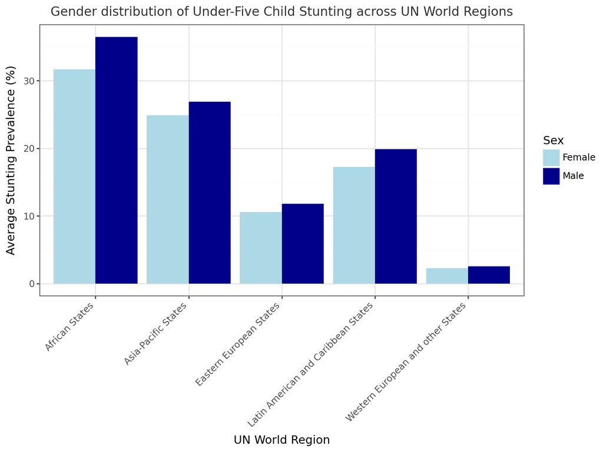

```python
import pandas as pd
import plotnine
from plotnine import (
    ggplot,
    aes,
    geom_bar,
    facet_wrap,
    labs,
    theme_bw,
    theme,
    scale_fill_manual,
)
data = {
    'World_region_by_UN': ['African States', 'Asia-Pacific States', 'Eastern European States',
                          'Latin American and Caribbean States', 'Western European and other States'],
    'Female': [31.69, 24.89, 10.57, 17.23, 2.24],
    'Male': [36.48, 26.90, 11.76, 19.88, 2.54]
}
df = pd.DataFrame(data)
df_melted = df.melt(id_vars='World_region_by_UN', value_vars=['Female', 'Male'],
                    var_name='Sex', value_name='Stunting Prevalence (%)')
(ggplot(df_melted, aes(x='World_region_by_UN', y='Stunting Prevalence (%)', fill='Sex'))
    + geom_bar(stat='identity', position='dodge')
    + labs(
        title='Gender distribution of Under-Five Child Stunting across UN World Regions',
        x='UN World Region',
        y='Average Stunting Prevalence (%)'
    )
    + scale_fill_manual(values={"Female": "#ADD8E6", "Male": "#00008B"})
    + theme_bw()
    + theme(plot_title=element_text(
         size=12,
         hjust=0.5,
         color="#333333"
     ),
     axis_text_x=element_text(rotation=45, hjust=1)
 )
    + theme(figure_size=(8, 6))
)
```

Several studies have been conducted to identify if sex is a risk factor for stunting. It seems that **boys are slightly more at risk of stunting**, as they seem to be **more susceptible to infectious diseases.**

Now, we will study the geographical repartition of under five child stunting cases. The map below shows **the prevalence of stunting in children under five around the world** between 2000 and 2022.

**Did you know ?**

In 2012, the World Health Organization (WHO) defined any country with **a stunting prevalence rate above 5% as “out of track”**.

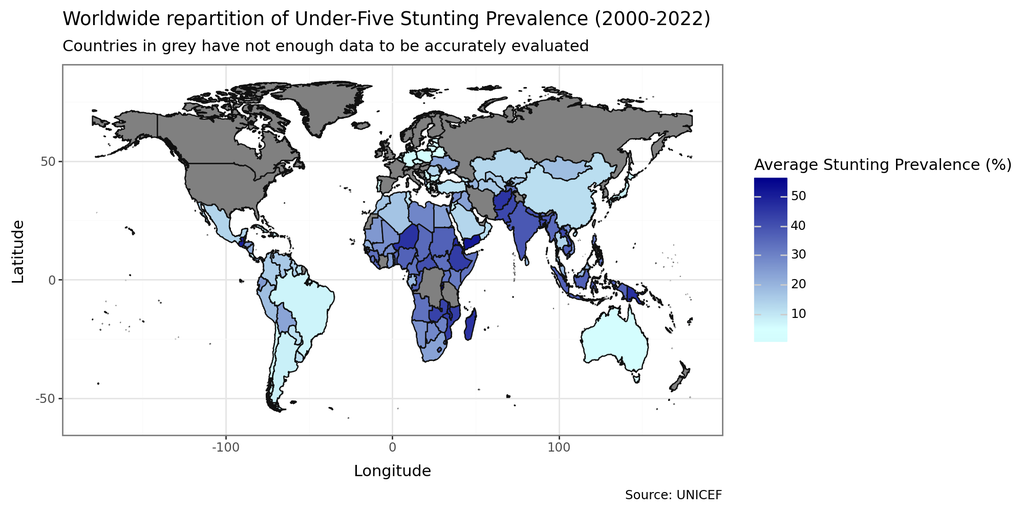

```python
import pandas as pd
import geopandas as gp
import plotnine
from plotnine import (
    ggplot,
    aes,
    geom_map,
    scale_fill_gradient2,
    labs,
    coord_fixed,
    theme_bw,
    theme,
    element_text
)
df_stunting = pd.read_excel("unicef_indicator_2_quarto_vo.xlsx")
df_stunting['time_period'] = pd.to_numeric(df_stunting['time_period'], errors='coerce').astype('Int64')
df_stunting_total = df_stunting[
    (df_stunting['sex'] == 'Total') & (df_stunting['time_period'] >= 2000) & (df_stunting['time_period'] <= 2022)
].copy()
df_stunting_avg = df_stunting_total.groupby('country')['stunting_prevalence_pourcentage'].mean().reset_index()
world = gp.read_file("https://public.opendatasoft.com/api/explore/v2.1/catalog/datasets/world-administrative-boundaries/exports/shp")
world = world.rename(columns={'name_long': 'name'})
df_merged = world.merge(df_stunting_avg, left_on='name', right_on='country', how='left')
(ggplot(data=df_merged, mapping=aes(fill='stunting_prevalence_pourcentage', map_id='name'))
    + geom_map()
    + scale_fill_gradient2(
        low='lightblue',
        mid='#D6FFFF',
        high='darkblue',
        midpoint=5,
        name='Average Stunting Prevalence (%)',
        na_value='grey')
    + labs(
        title="Worldwide repartition of Under-Five Stunting Prevalence (2000-2022)",
        subtitle="Countries in grey have not enough data to be accurately evaluated",
        caption="Source: UNICEF",
        x="Longitude",
        y="Latitude",
        fill="Average Stunting Prevalence (%)"
    )
    + theme_bw()
    + theme(figure_size=(10,5)))
```

Indeed, as stunting is a consequence of chronic malnutrition, untreated infections, unsafe water sources, limited access to education and healthcare, and severe poverty, we can find **high stunting prevalence in countries with low income and high instability**. This explains why we can observe the **highest concentration** of stunting among under five children on **the African continent and in South Asia**.  
The **five countries** with the **highest stunting prevalence rates** *(average calculated between 2012 and 2022)* are :  
- **Burundi**;  
- **Timor-Leste**;  
- **Yemen**;  
- **Guatemala**;  
- **Madagascar**.

They all present a **rate superior to 40%**.  
These countries are located in **low income regions** where progress has been particularly slow with no quick fix solutions. **Conflicts, climate vulnerability, weak governance structures, and limited healthcare systems** make any international intervention harder to plan & execute, encouraging stagnant stunting rates.

# **Is there still hope?**

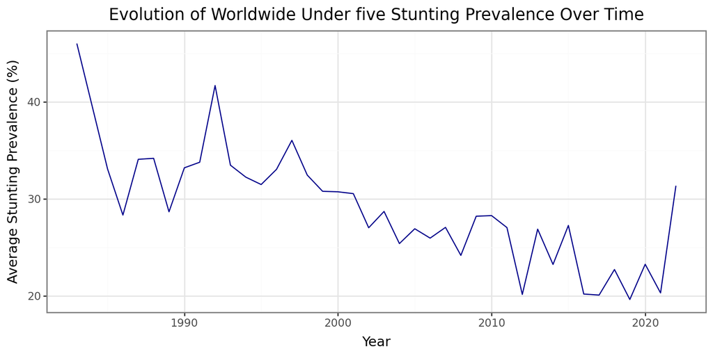

```python
import pandas as pd
import plotnine
from plotnine import (
    ggplot,
    aes,
    geom_line,
    labs,
    theme_bw,
    theme
)
df = pd.read_excel("unicef_indicator_2_quarto_vo.xlsx")
df['time_period'] = pd.to_numeric(df['time_period'], errors='coerce')
df_grouped = df.groupby('time_period')['stunting_prevalence_pourcentage'].mean().reset_index()
df_grouped = df_grouped.rename(columns={'stunting_prevalence_pourcentage': 'average_stunting_prevalence'})
(ggplot(df_grouped, aes(x='time_period', y='average_stunting_prevalence'))
    + geom_line(color='darkblue')
    + labs(
        title='Evolution of Worldwide Under five Stunting Prevalence Over Time',
        x='Year',
        y='Average Stunting Prevalence (%)'
    )
    + theme_bw()
    + theme(figure_size=(8, 4))
)
```

Globally, there has been **a clear decrease** in the prevalence of stunting over the past two decades. This was achieved thanks to **coordinated international efforts** that committed to **provide a better access to food, water and general maternal health & hygiene**. However, despite the significant progress, we can observe on the graph that **recent years have seen a resurgence of stunting cases**. This could be explained by the apparition of new violent conflicts such as the Russian-Ukrainian war, or the current bombing of Gaza. This shows that **efforts to reduce stunting** are still **essential to protect children**.  
The **WHO and UNICEF** have now set up **a global objective to reduce the number of stunted children under five by 40% by 2025**. To achieve this, countries should implement a **comprehensive strategy** that include interventions in **nutrition, health, education and hygiene**.  
**While significant challenges persist**, this global progress proves that with **continued collaboration we could meet WHO and UNICEF’s targets**.

> The cause of making the world a better place for children unites us all.

Liam NEESON, Actor